# Installing Arch on VMware Workstation

# Installing Arch Linux on VMware Workstation

## Before you begin

To install Workstation Player 14, VMware recommends(Vmware, n.d.) that you have the following: 1. An Intel CPU with VT-x support or an AMD CPU with AMD-V support. 2. 2 GB of RAM (4 GB or higher recommended) 3. A 16- or 32-bit display adapter 4. At least 1 GB of hard drive space

A list of these requirements can be found at the VMware Docs site.

To install Arch Linux, you must have an x64_86-compatible PC with at least 512MB of RAM and 800 MB of disk space available(Dario Giova, n.d.). Oh, and an active internet connection.

## Getting VMware Workstation Player

To download VMware Workstation Player 14.1, visit [my.vmware.com](https://my.vmware.com/en/web/vmware/free#desktop_end_user_computing/vmware_workstation_player/14_0) and click on the link to download. This will download the file in a `.bundle` package which must be installed from the command line. To run the installer in Linux, use the command

```
$sudo bash VMware-Player-*.x64_86.bundle
```

After this, an installer window will open asking if you accept their ToS/EULA. It will also ask for a path for system scripts, as well as a product key.

I installed VMware Workstation Player 14.1 on a system already running Arch Linux, and had to install [vmware-patch](https://aur.archlinux.org/packages/vmware-patch/) to get player to detect my kernel.

Next we can get the Arch image.

## Getting Arch Linux

To download the image file for installation, go to the [Arch Linux Download page](https://www.archlinux.org/download/) and select a mirror. (I chose the [cat.pdx.edu](http://mirrors.cat.pdx.edu/archlinux/iso/2018.02.01/) mirror) Alternatively, you can download a torrent and get it from there, but don’t forget to seed.

## Setting up your virtual machine

To set up your virtual machine, start VMware Workstation player and hit create a new virtual machine. You will be prompted to chose where to install the operating system from, so hit the “Use ISO image” radio button and point to the Arch .iso you just downloaded. Next, you select “Linux”" and “Other Linux 4.x Kernel” from the dropdown. You’ll be prompted to select a location to store your VM and then you will have to chose how big the hard drive you want. I went with the default 8 GB but you can use however much space you would like, provided you have the storage to do so. You can keep the default for virtual disk splitting selected and then hit next.

Finally, you will be brought to a window that says “Ready to Create Virtual Machine”, but we aren’t. Select “Customize Hardware” and a new window will pop up, shown below:

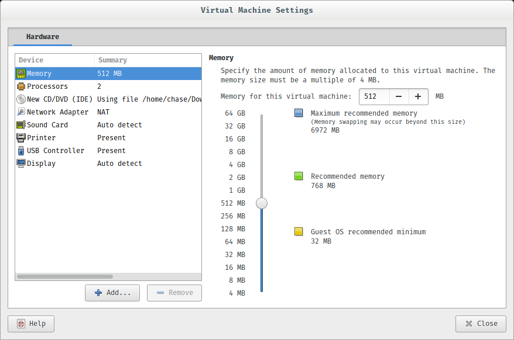

Change the memory to the amount you want (remember, 512 MB is the bare minimum) and set the number of CPU to how many cores your host CPU has (if you are unsure, it’s okay to keep the value at 1). You can also click the Display tab and hit “3D Acceleration”.

Now you can hit close and finish the setup. Make sure you uncheck the “power on” selector before you finish, there’s one more step we need to accomplish before we get into things. Go to the folder that you selected to store your VM and open the `xx.vmx` file with a text editor (Don’t double click it!). We’re going to add the line

```
firmware = "efi"
```

to the very bottom of the file and then save it.

Now you’re ready to power on the system. You can double click the file you just edited, or open it through VMware workstation.

## Installing Arch

Wait until the system loads the operating system splash screen, which will be similar to the one below:

[figure not shown]

Select `Boot Arch Linux (x64_86)` and wait for the machine to load the installer from the .iso.

You will immediately be put into a command line interface. If this scares you, it shouldn’t. I will be here to guide you through the installation.

Type

```
$ ls /sys/firmware/efi/efivars
```

You can use tab completion after the first couple letters of each of the sub folders. If everything is done correctly, you should get an output similar to mine:

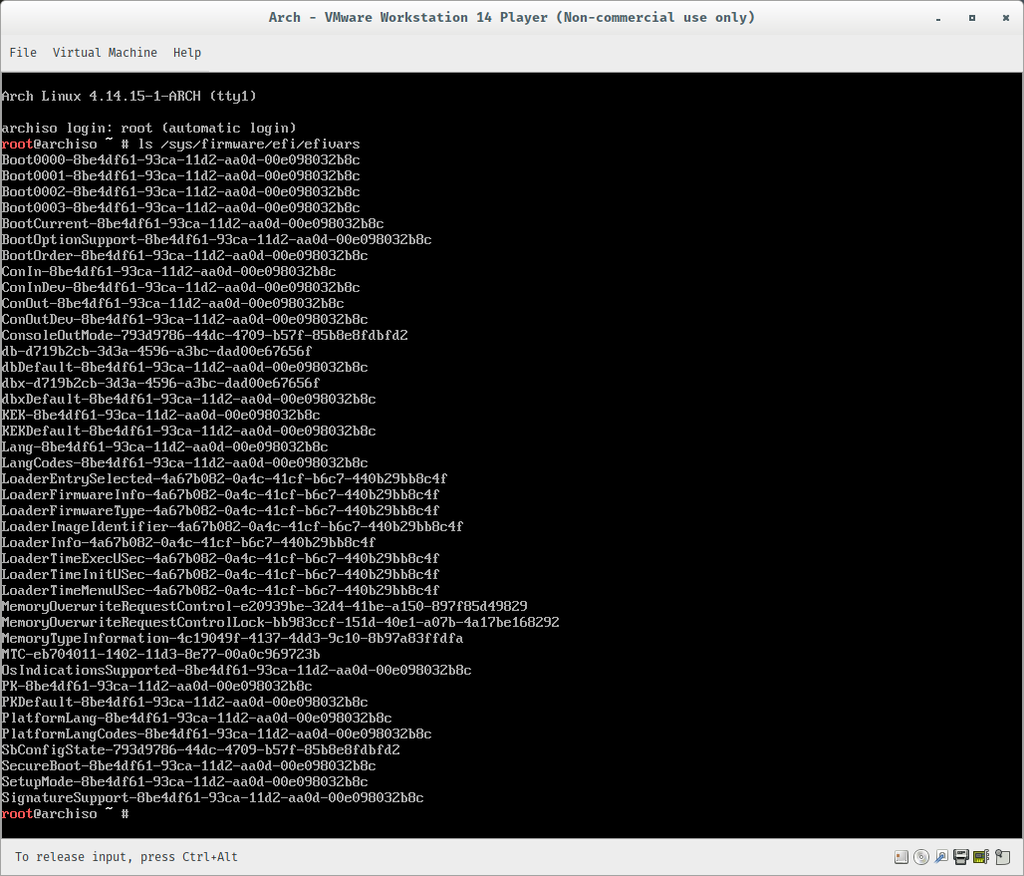

This means that you have EFI running. This is exactly what we want.

Next, we have to check that we have access to the internet. Type

```
$ ping -c www.google.com
```

If you don’t get any errors, you’re good to go.

Next, type

```
$ timedatectl set-ntp true
```

This will set the system clock.

### Partitioning your hard disk

The next part will be a little finicky. Type

```
$ lsblk
```

and you will get an output like this:

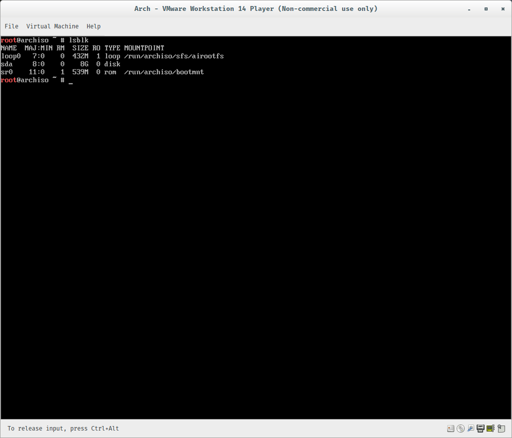

The drive that we want should be some form of `sdX` where `X` is a letter. In my case, it is `sda`. This is the drive we want to partition. Type

```
$ cfdisk /dev/sda
```

and you will be brought to a partition wizard.

Make sure that you select the proper filesystem types: Your boot partition should be Microsoft basic data, your swap should be Linux swap, and your home and root partitions should be Linux filesystem. You should have something like this when you’re done:

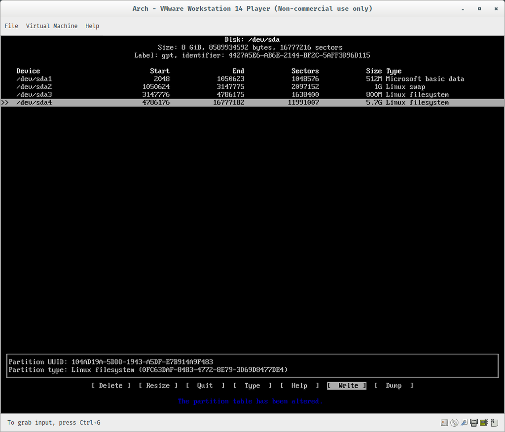

Don’t forget to hit Write before you quit. Now if you type

```
$ lsblk
```

you should see

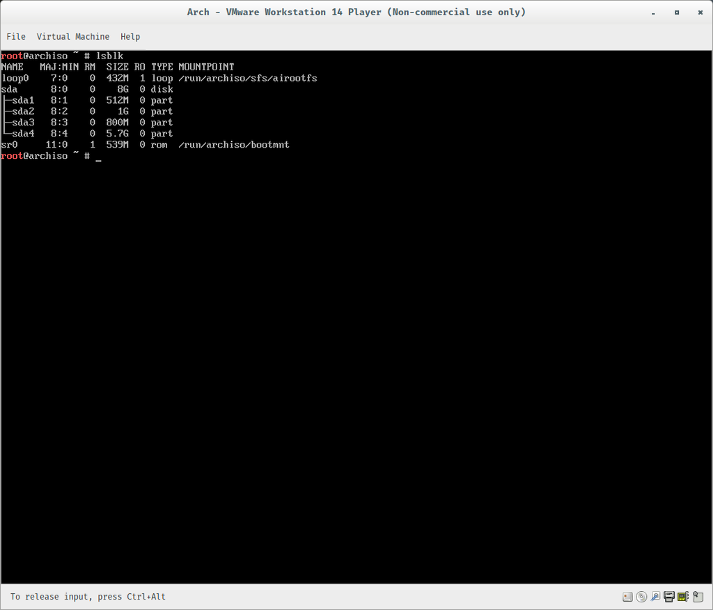

```
$ mkfs.vfat -F32 /dev/sda1
$ mkswap /dev/sda2
$ mkfs.ext4 /dev/sda3
$ mkfs.ext4 /dev/sda4
$ swapon /dev/sda2
```

We just set the file system to fat32 for the boot partition, swap on the swap partition, and ext4 for the root and home partitions. After that, we told the computer to use the swap partition as swap.

Now we can actually mount them:

```
$ mount /dev/sda3 /mnt
$ mkdir /mnt/boot
$ mkdir /mnt/home
$ mount /dev/sda1 /mnt/boot
$ mount /dev/sda4 /mnt/home
```

If everything went according to plan, you have the skeleton of your Arch install all set up. Now we can get into the actual nuts and bolts of the installation, and the hard part is over with. If we run our trusty `$lsblk`, we should see

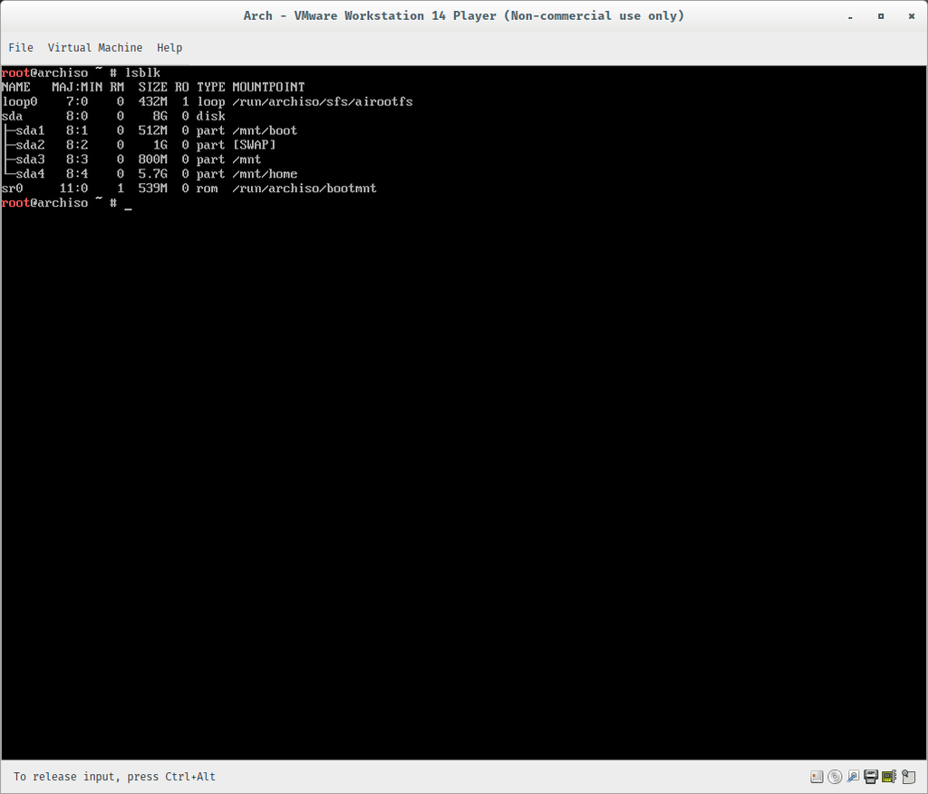

### Finding a mirror

This is where the actual installation part comes into play. First, we need to edit our mirror to find the best one to download from. Point your browser to the [Mirror Status](https://www.archlinux.org/mirrors/status/) page and select a mirror you want to use there. I like to go down to the part of the window that says *Sucessfully Syncing Mirrors* and then sort the list by highest mirror score. Then I select the highest scoring mirror that is near me. Your mileage may vary.

[figure not shown]

I am going to use a mirror in the United States, [clarkson.edu](http://mirror.clarkson.edu/archlinux/). To use this mirror, you need to edit `/etc/pacman.d/mirrorlist` so that the mirror is at the type. type

```
$ nano /etc/pacman.d/mirrorlist
```

and then add `Server = http://mirror.clarkson.edu/archlinux/$repo/os/$arch` to the top of the list, above `## China`.

Hit `Ctrl + x` to save, follow the prompts and quit. Now we can finally install Arch!

### Pacstrap

Now that we’ve edited the mirror list, we can install Arch. Type

```
$ pacstrap -i /mnt base base-devel
```

and hit enter. You will be prompted to make some choices, just hit enter to accept the defaults and then hit y. The files will begin to download and install, so sit back, grab something to drink, do whatever. It might take a little while.

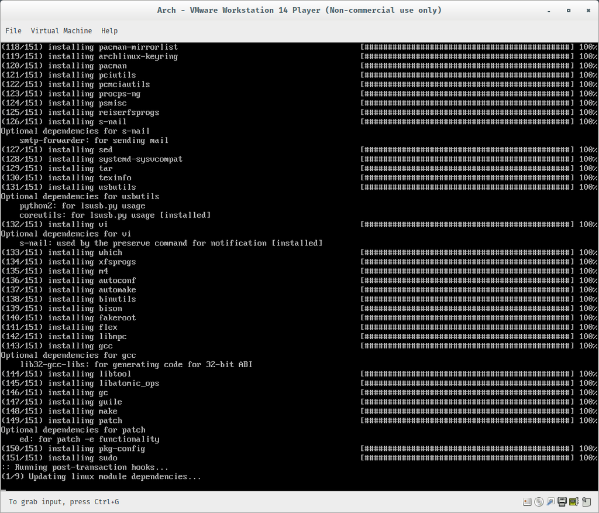

Screenshot

And all the heavy lifting is done! Let’s generate our filesystem table

```
$ genfstab /mnt >> /mnt/etc/fstab
```

Now that we’ve generated the fstab, let’s take a look at it

```
$ nano /mnt/etc/fstab
```

If it looks similar to this, you’re good:

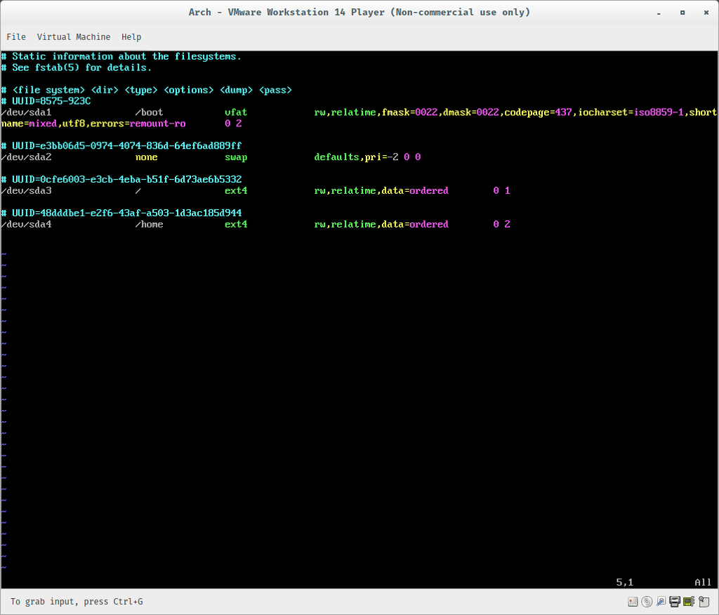

### arch-chroot

Now we need to set the OS up to be self-sufficient. First, we need to arch-chroot into the filesystem.

```
$ arch-chroot /mnt
```

First things first, let’s select a timezone and set the system clock:

```
$ ln -sf /usr/share/zoneinfo/America/New_York /etc/localtime
$ hwclock --systohc.
```

The first line sets a *symbolic link* between the time zone and your local time. You can use a different zone if you’re in a different area using the command `tzselect`.

Now, edit the file `/etc/locale-gen` to uncomment your language. I’m going to use `en_US.UTF-8 UTF-8`, but you can use whatever you would normally use. Do this by typing

```
$ nano /etc/locale.gen
```

and then deleting the # before the one(s) you want to use.

[figure not shown]

Save and exit, and then type

```
$ locale-gen
```

to finalize the change.

Next, set the language variable in `/etc/locale.conf` by typing

```
$ echo "LANG=en_US.UTF-8" >> /etc/locale.conf
```

We’re going to do something similar for our hostname. I’m choosing `archVM` for my hostname, so I’ll type

```
$ echo "archVM" >> /etc/hostname
```

and for hosts we’ll type

```
$ nano /etc/hosts
```

and edit it so that it looks like this:

```
127.0.0.1   localhost
::1         localhost
127.0.1.1   archVM.localdomain  archVM
```

Now we need to have systemd start the network connection on start up. To do this, type

```
$ systemctl enable dhcpcd.service
```

Let’s add a password to our root account by typing

```
$ passwd
```

and entering a password when prompted.

Finally, we need to install a *bootloader*.

### Installing a bootloader

I used to use a mac, and as a result I’m partial to rEFInd as a bootloader. To install this, we have a couple steps. First, type

```
$ pacman -S refind-efi
```

and accept the prompts when they come up.

Once this installs, we can type

```
refind-install
```

and we should get the output below:

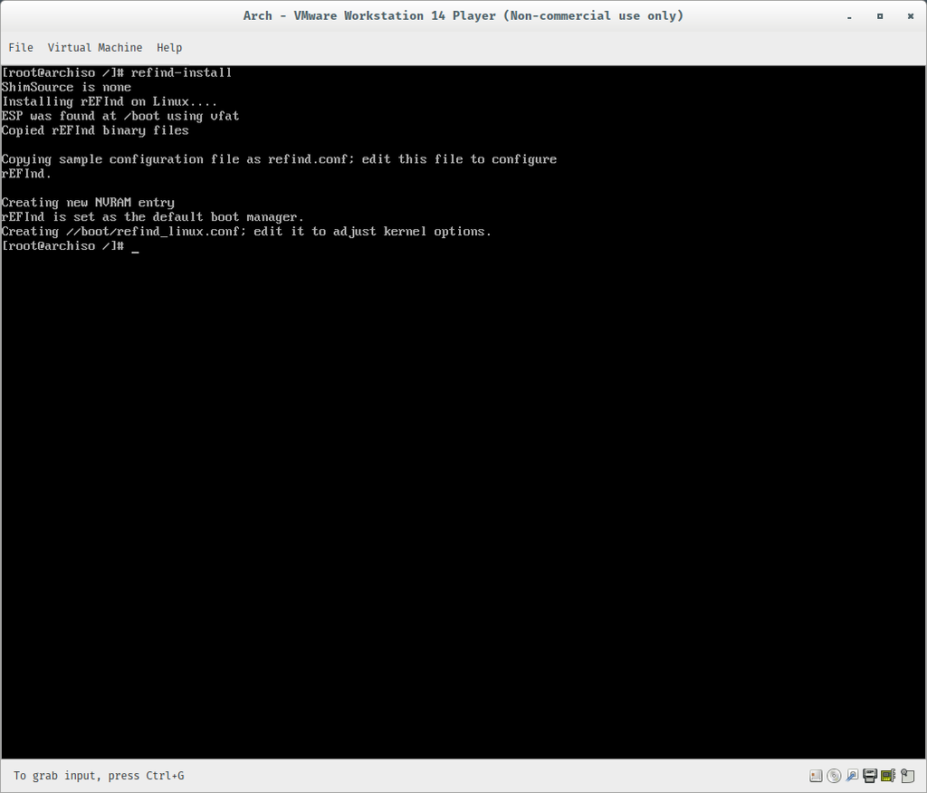

As a final step, we need to edit `/boot/refind_linux.conf` because when the install script populated it, it was populated with the values for the .iso and not our boot disc. To edit that, you need to change the file

```
$ nano /boot/refind_linux.conf
```

Basically, where you see the part that says something like `ro root=UUID-...-6d73ae6b5332`, it needs to be placed on the line `"boot with standard options"` and the other two need to be deleted. Also, replace the `ro` with `rw`. When all is said and done, you should have something that looks like this:

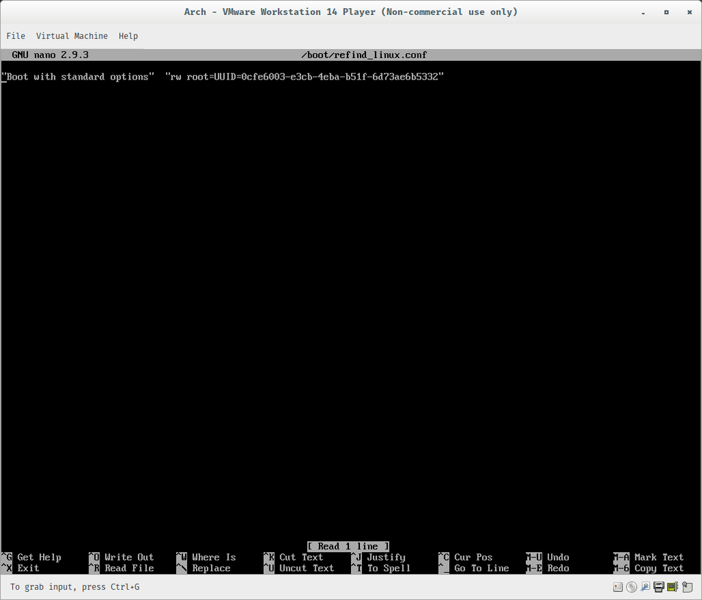

save your changes, you’re in the home stretch!

### Finishing touches

Now that we’re done, we can exit `arch-chroot` and finish our install.

```
$ exit
```

You’ll be kicked out of chroot jail, and ready to leave the installer limbo. Type

```
$ umount -R /mnt
```

You shouldn’t have any errors at this point. If you do, there’s a chance you left the `/root` directory when you were in chroot. To fix this you can just `$arch-chroot /mnt` back in, type `$ cd`, and then `$ exit` and try again. At this point, you’re finished with installing. Type

```
$ reboot
```

and cross your fingers; with any luck you’ll see

[figure not shown]

Push enter and rEFInd will load into the OS. You’ll be greeted with this screen:

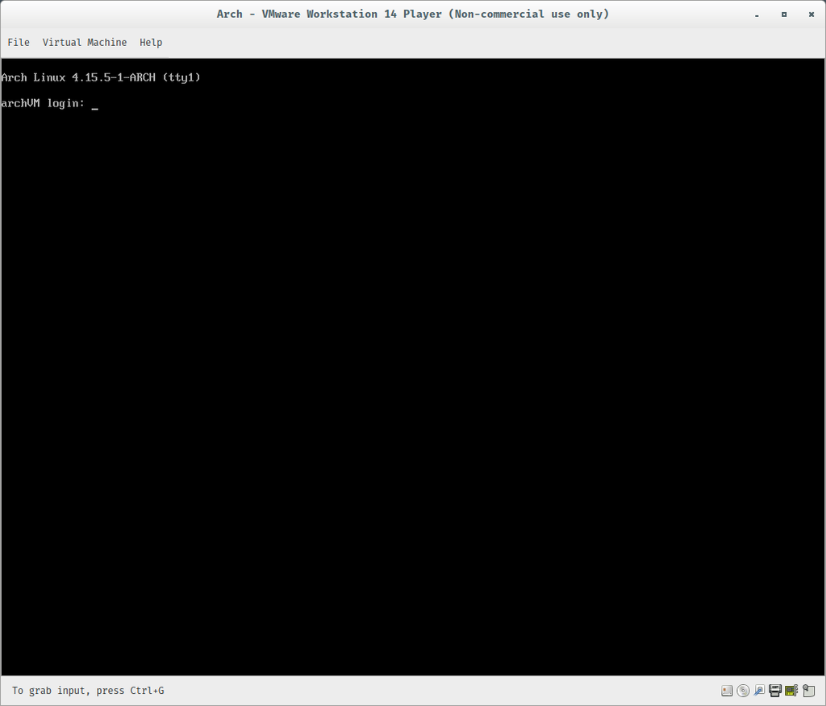

Screenshot

Congratulations! You just installed Arch Linux in a VM!

# References

Dario Giova, et al, Jakub Klinkovský. n.d. “Arch Linux Installation Guide.” https://wiki.archlinux.org/index.php/Installation_guide.

Vmware, Inc. n.d. “Host System Requirements for Workstation Player.” https://docs.vmware.com/en/VMware-Workstation-Player-for-Linux/14.0/com.vmware.player.linux.using.doc/GUID-3CF87F1D-FD14-4FBA-A00C-F13D65825CA5.html.